# 2021-11-03

# Wind rose map

We first look at one station, `945959`:

- **A**: Plot the counts of wind from each direction from Oct-2019 to Mar-2020
- **B**: Use polar coordinate on A
- **C**: Remove grid lines and theme, to inset into the map
- Wind direction aggregate to every 20 degree - 10 degree looks too sparse

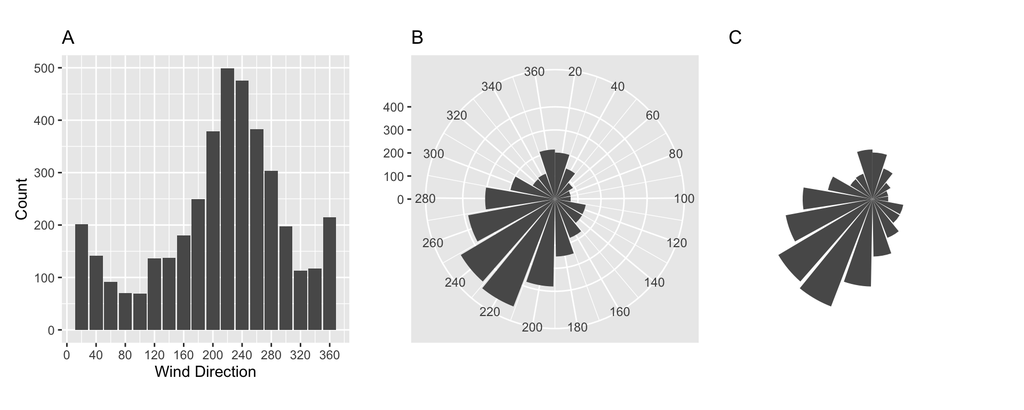

## All the stations:

- Slightly rearrange the coordinate to be multiple of 0.4 to avoid wind rose inset overlapping

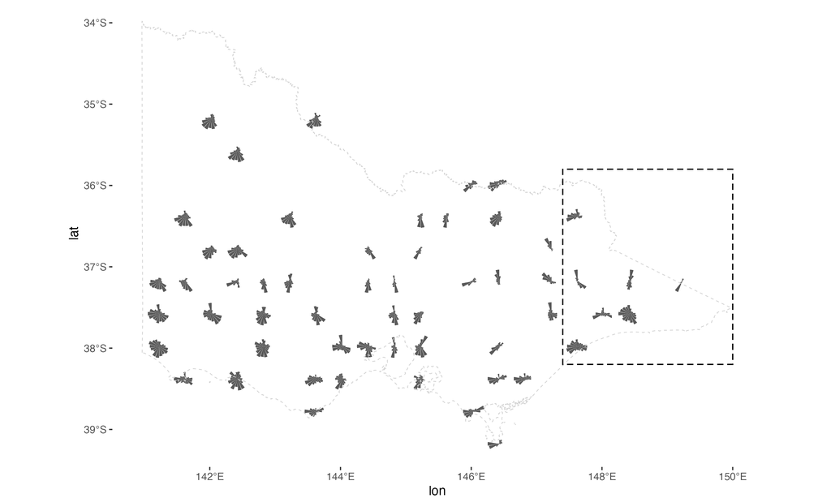

- Wind pattern in west and middle are easy to follow but eastern Victoria is a bit harder to follow
- Pick area in the bounding box as the target.
- Can further look into the wind direction and speed for small periods when there’s a fire in the area. Need extra data of fire date and location to do so.

# Area unavailable for placing wind sensor

- This section zooms into the area in the box from the wind rose plot to map out the possible location for placing wind sensors.
- Use [OpenStreetMap](https://wiki.openstreetmap.org/wiki/Map_features#Waterway) for different features. This can be an alternative to the ALUM data.
- Need to read WMO’s guide online on placing meteorological instruments
- **script**: Query of OpenStreetMap is in `script/05-OpenStreetMap.r`
- **data**: all the `osmdata` object is named as `osm_xxx` and saved under `data/osm/osm_xxx.rda`. The post-processed line, polygon, and multipolygons of each osmdata object is saved under `data/osm-processed/osm_xxx.rda`. This includes:
  - `water`,
  - `wetland`, `wetland_multipoly`
  - `lake`, `lake_multipoly`
  - `waterway`, `waterway_poly`
  - `protected_area`, `protected_area_multipoly`
  - `nature_reserve`, `nature_reserve_multipoly`
  - `highway`
  - `woodtree`, `woodtree_multipoly`

Here we gradually mark up different categories that are unavailable to place the sensor and in the end find the complement for the available region.

## Water

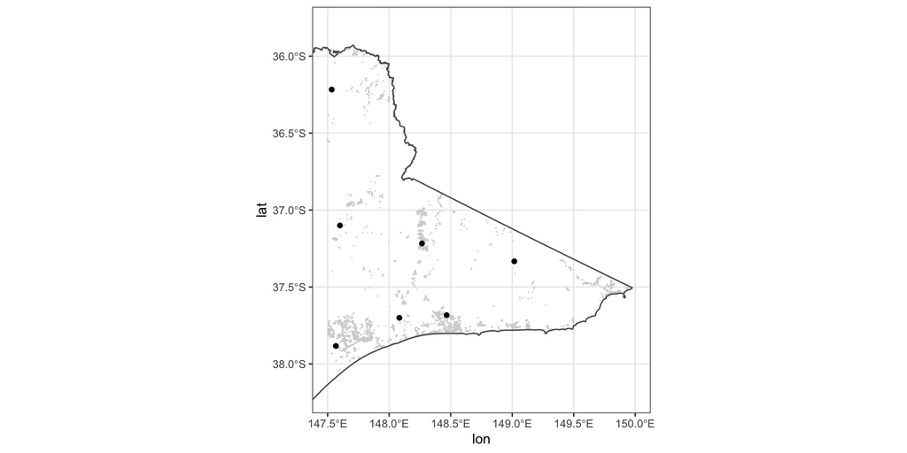

## Lake

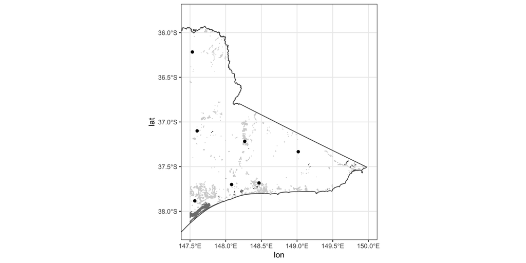

## Waterway

- Waterway can be hard to decide: it includes river, stream, drain, canal, dam, weir, and ditch

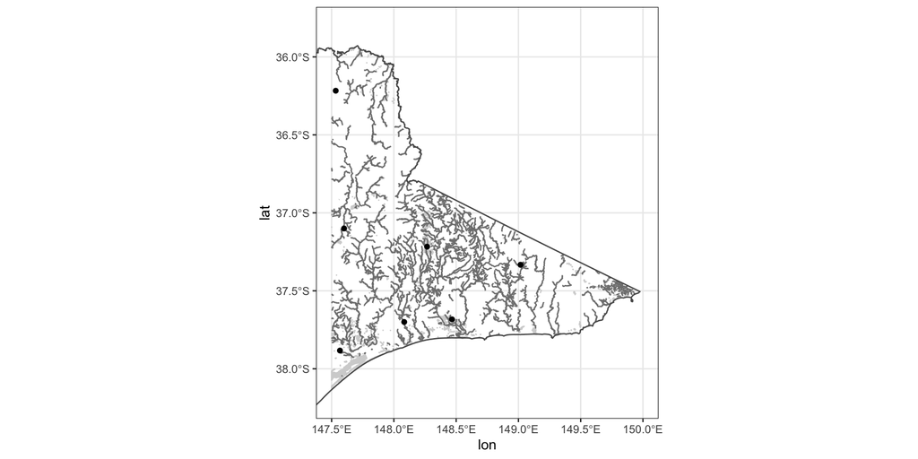

## Nature reserve/ protected area

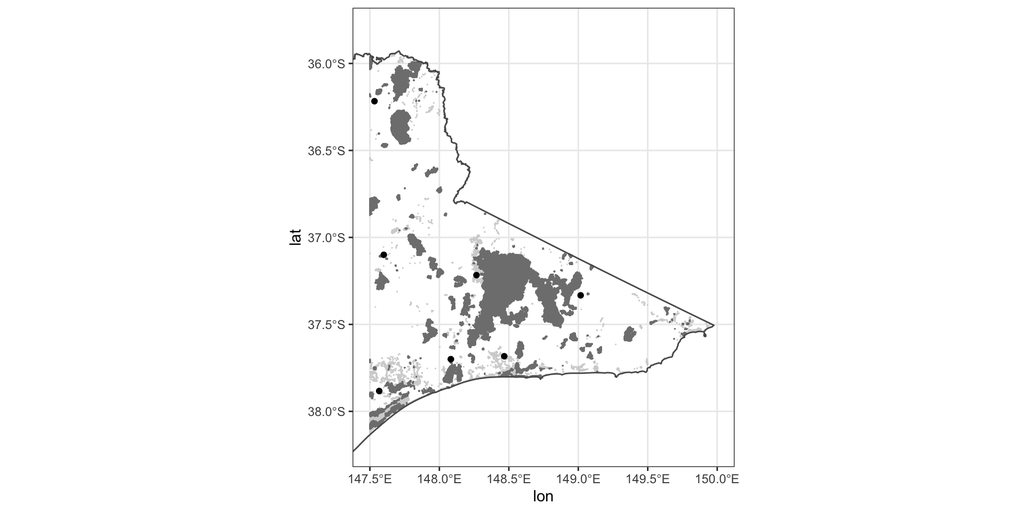

# Highway

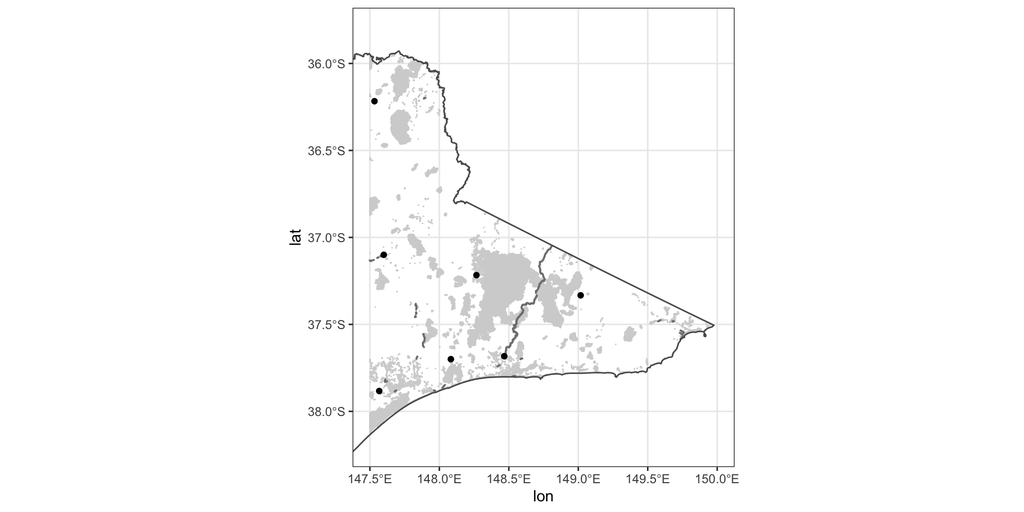

# Wood, tree

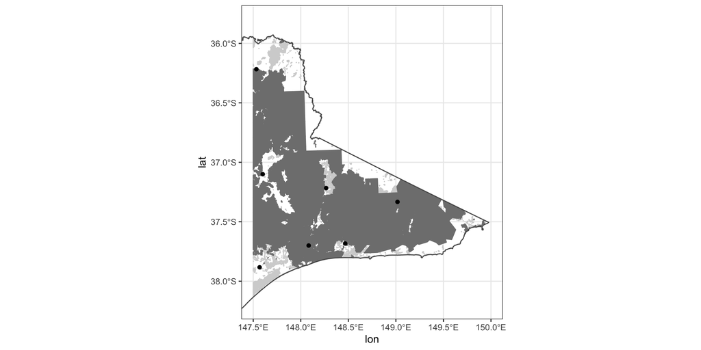

## What’s left:

- This is the final markup combining all the elements above:

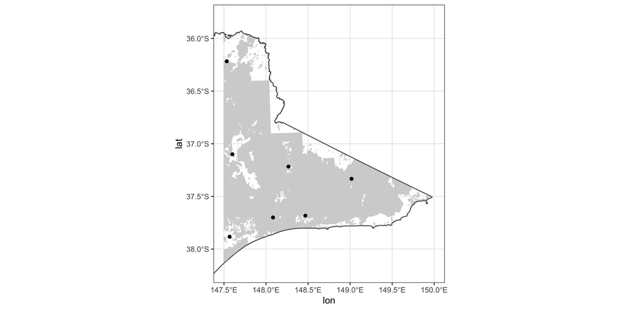